# Midterm Project

### Bias in the Workplace: Unemployment

Diversity and inclusion in the workplace is an important topic in todays day and age. Due to anti-discrimination laws many businesses attempt to provide a diverse and inclusive work environment for their staff, however, the attempts are not always so successful. One of the factors that impact diversity in the workplace is bias, specifically implicit or unconscious bias ([Impact Group](https://www.impactgrouphr.com/insights/unconscious-bias)). Implicit bias is not based conscious decisions, but subconscious ideas that can influence a decision. For example, a common type of implicit bias is the affinity bias which states that people are more likely to associate with others who share similar traits. As people tend to like other people similar to them, affinity bias can decrease diversity in the workplace. Affinity bias isn't the only implicit bias that can be seen in the workplace. Studies such as [this one](https://www.tandfonline.com/doi/abs/10.1080/0361073X.2013.808111?casa_token=80xXV3TbU3oAAAAA%3AKPvWAAMs6GNG_rEqhbEf5-KnBrRUGSvguZgKrBgF2zukfb5t7QGrIIQS4ByfF2Z45Dj16IurC301&journalCode=uear20) discuss the prevalence of agism in the workplace. Another [study](https://journals.sagepub.com/doi/10.1177/000312240406900303) based on survey data indicates that white men are favored in the workplace compared to women or men of a different race.

While implicit biases are seen most commonly in the [hiring stage](https://www.crowdstaffing.com/blog/hidden-bias-that-affect-the-hiring-process), bias can be carried over to firing employees as well. By analyzing unemployment data I can determine the types of bias, if any, are prevalent in the stage of termination.

To determine if there is bias present in the workplace the following questions can be asked:

1. Is there a difference in unemployment rate across races?
2. Is the unemployment rate higher among younger or older age groups?
3. What about gender? Are women unemployed at a higher rate than men?

### Data

The data I will be analyzing comes from the [US Bureau of Labor Statistics](https://www.bls.gov/). The BLS has many relevant data sets that will be used in my analysis:

- [Civilian unemployment rate](https://www.bls.gov/charts/employment-situation/civilian-unemployment-rate.htm)
- [Unemployment rates by age, sex, and marital status, seasonally adjusted](https://www.bls.gov/web/empsit/cpseea10.htm)

```python
import pandas as pd
import matplotlib.pyplot as plt
from scipy import stats
import numpy as np
import math

cbi = pd.read_csv("data/change by industry.csv")
rate = pd.read_csv("data/civilian unemployment rate.csv")
rate_by_age = pd.read_csv("data/age sex and marital status.csv")
industry = pd.read_csv("data/employment by industry.csv")

for column in industry:
    if column != 'Month' and column != 'Mining and logging' and column != 'Utilities':
        industry[column] = industry[column].str.replace(",", "").astype(float)
cbi['Employed (thousands)'] = cbi['Employed (thousands)'].str.replace(',', "").astype(float)
cbi['12-month net change (thousands)'] = cbi['12-month net change (thousands)'].str.replace(',', "").astype(float)

rate.rename(columns={"Men, 20 years and over":"Men"}, inplace=True)
rate.rename(columns={"Women, 20 years and over":"Women"}, inplace=True)
```

### Ethical Concerns

It is important to consider the ethical impacts of analyzing data. The results of my analysis could be used to tailor discrimination laws in regards to termination. [Federal anti-discrimination laws](https://www.ftc.gov/site-information/no-fear-act/protections-against-discrimination) are already in place to prevent employers from discriminating on the basis of race, gender, or age. However, policy makers can tweak current policies or write new ones in an additional attempt to prevent possible discrimination that may be found during this analysis.

The analysis of such data can have direct and indirect impacts on people. Some of the direct stakeholders would include employers and their employees. Employers may take these results into consideration when terminating their next employee, and the employees are directly impacted by the possibility of unemployment. The direct stakeholders hold similar values as both employees and employers should value diversity in the workplace. [Eric Feigenbaum](https://smallbusiness.chron.com/value-diversity-workplace-3035.html) is one of many to explain the benefits and importance of diversity in the workplace. Indirect stakeholders would include policy makers, government, and the families of employees. In addition to policy makers and employers, researchers studying discrimination and bias in the workplace could also benefit from the results of my analysis. The stakeholders, values, and possible applications of the results are taken into consideration throughout the analysis.

## Unemployment by Race

#### Visualization

Plotting unemployment rate by race from 2001 to 2021

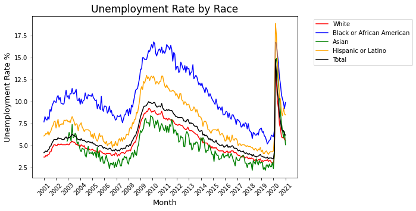

```python
plt.rcParams['figure.figsize']=(8,5)

plt.plot(rate['Month'][:], rate['White'][:], color='red')
plt.plot(rate['Month'][:], rate['Black or African American'][:], color='blue')
plt.plot(rate['Month'][:], rate['Asian'][:], color='green')
plt.plot(rate['Month'][:], rate['Hispanic or Latino'][:], color='orange')
plt.plot(rate['Month'][:], rate['Total'][:], color='black')

plt.xticks(rotation=45)
labels = ['White', 'Black or African American', 'Asian', 'Hispanic or Latino', 'Total']
plt.legend(bbox_to_anchor=(1.05, 0.8, 0.3, 0.2), loc='upper left', labels=labels)
plt.ylabel("Unemployment Rate %", size=13)
plt.xlabel("Month", size=13)
ticks = []
months = []
for i in range(0, len(rate['Month']), 12):
    ticks.append(i)
    months.append(rate['Month'][i].replace("Feb ", ""))
plt.xticks(ticks, months)
plt.title("Unemployment Rate by Race", size=17)
plt.show()
```

Looking at the visualization above, the blue and orange lines look to be consistantly above the black line. This would mean that the unemployment rate for Black or African American and Hispanic or Latino people is greater than the total average. On the other hand, the red and green lines both look like they are below the black line. These lines would correlate to White and Asian people having lower unemployment rates than the total average.

```python
print("Black or African American average: ", rate['Black or African American'].mean())
print("Hispanic or Latino average:        ", rate['Hispanic or Latino'].mean())
print("Total average:                     ", rate['Total'].mean())
print("White average:                     ", rate['White'].mean())
print("Asian average:                     ", rate['Asian'].mean())
```

```
Black or African American average:  10.583402489626556
Hispanic or Latino average:         7.670539419087137
Total average:                      6.097510373443984
White average:                      5.404979253112033
Asian average:                      4.886697247706423
```

While the means themselves have different values, the differences aren't necessarily significant. To determine if there is an actual significant difference between the total average unemployment rate and that of certain racial groups, statistical tests can be conducted.

#### Statistical Testing

The Mann-Whitney rank test is an appropriate non-parametric test for this independent data. The null hypothesis in every test will be that the sample mean is equal to the population mean. H<sub>0</sub>: $\mu$<sub>race</sub> = $\mu$<sub>total</sub>

The first set of tests will be conducted with an alternative hypothesis that the sample mean is not equal to the population mean: H<sub>a</sub>: $\mu$<sub>race</sub> != $\mu$<sub>total</sub>

```python
print("White mean != Total mean:                     p = ", stats.mannwhitneyu(rate['White'], rate['Total']).pvalue)
print("Asian mean != Total mean:                     p = ", stats.mannwhitneyu(rate['Asian'], rate['Total']).pvalue)
print("Black or African American mean != Total mean: p = ", stats.mannwhitneyu(rate['Black or African American'], rate['Total']).pvalue)
print("Hispanic or Latino mean != Total mean:        p = ", stats.mannwhitneyu(rate['Hispanic or Latino'], rate['Total']).pvalue)
```

```
White mean != Total mean:                     p =  7.446586637749099e-07
Asian mean != Total mean:                     p =  2.642731786827147e-07
Black or African American mean != Total mean: p =  1.047455665291668e-53
Hispanic or Latino mean != Total mean:        p =  3.2674131297136267e-13
```

All four of the tests above resulted in a p-value that is less than 0.05. Because the p-value is so small in every test, all four alternative hypotheses can be accepted. The average unemployment rates among each race group are statistically significantly different from the total average unemployment rate.

The previous tests were conducted with a simple alternative hypothesis that $\mu$<sub>race</sub> != $\mu$<sub>total</sub>. Additional statisical tests can also be conducted with more specific alternative hypotheses based on the means calculated above.

- H<sub>a</sub>: $\mu$<sub>white</sub> < $\mu$<sub>total</sub>
- H<sub>a</sub>: $\mu$<sub>asian</sub> < $\mu$<sub>total</sub>
- H<sub>a</sub>: $\mu$<sub>black</sub> > $\mu$<sub>total</sub>
- H<sub>a</sub>: $\mu$<sub>hispanic</sub> > $\mu$<sub>total</sub>

```python
#red line is below black line, white mean < total mean
p = stats.mannwhitneyu(rate['White'], rate['Total'], alternative='less')
print("White < Total:                     p value = ", p.pvalue)
#green line is below black line, asian mean < total mean
p = stats.mannwhitneyu(rate['Asian'], rate['Total'], alternative='less')
print("Asian < Total:                     p value = ", p.pvalue)
#blue line is above black line, black mean > total mean
p = stats.mannwhitneyu(rate['Black or African American'], rate['Total'], alternative='greater')
print("Black or African American > Total: p value = ", p.pvalue)
#orange line is above black line, hispanic mean > total mean
p = stats.mannwhitneyu(rate['Hispanic or Latino'], rate['Total'], alternative='greater')
print("Hispanic or Latino > Total:        p value = ", p.pvalue)
```

```
White < Total:                     p value =  7.446586637749099e-07
Asian < Total:                     p value =  2.642731786827147e-07
Black or African American > Total: p value =  1.047455665291668e-53
Hispanic or Latino > Total:        p value =  3.2674131297136267e-13
```

The p-values for these four tests are all less than 0.05. Similar to the first set of tests, all four of the alternative hypotheses can be accepted.

The following statements can be made

- $\mu$<sub>white</sub> < $\mu$<sub>total</sub>: White people have a significantly lower unemployment rate than the average
- $\mu$<sub>asian</sub> < $\mu$<sub>total</sub>: Asian people have a significantly lower unemployment rate than the average
- $\mu$<sub>black</sub> > $\mu$<sub>total</sub>: Black or African American people have a significantly greater unemployment rate than the average
- $\mu$<sub>hispanic</sub> > $\mu$<sub>total</sub>: Hispanic or Latino people have a significantly greater unemployment rate than the average

## Unemployment by Age

The data used in this portion of the analysis comes from the rates_by_age dataset. This set contains the unemployment rates for every month in the range of February 2020 to February 2021. The rates are broken down by age with 12 ranges starting at 16 years old to 55 years and older.

```python
rate_by_age.loc[range(2, 14),:]
```

|  | Age, sex, and marital status | 2020 | Unnamed: 2 | Unnamed: 3 | Unnamed: 4 | Unnamed: 5 | Unnamed: 6 | Unnamed: 7 | Unnamed: 8 | Unnamed: 9 | Unnamed: 10 | Unnamed: 11 | 2021 | Unnamed: 13 |
| --- | --- | --- | --- | --- | --- | --- | --- | --- | --- | --- | --- | --- | --- | --- |
| 2 | Total, 16 years and over | 3.5 | 4.4 | 14.8 | 13.3 | 11.1 | 10.2 | 8.4 | 7.8 | 6.9 | 6.7 | 6.7 | 6.3 | 6.2 |
| 3 | 16 to 19 years | 11.5 | 14.1 | 32.1 | 29.6 | 22.6 | 19.1 | 16.4 | 16.3 | 14 | 13.9 | 16 | 14.8 | 13.9 |
| 4 | 16 to 17 years | 10.7 | 16.3 | 28 | 29 | 23.2 | 17.7 | 14.8 | 17.2 | 14.1 | 14.9 | 14.5 | 15.9 | 14.8 |
| 5 | 18 to 19 years | 12.2 | 12.8 | 34.2 | 29.5 | 22.3 | 20 | 17.6 | 15.8 | 14.1 | 13.4 | 17 | 14.2 | 13.7 |
| 6 | 20 years and over | 3.2 | 4 | 14.2 | 12.7 | 10.7 | 9.9 | 8.1 | 7.5 | 6.6 | 6.4 | 6.3 | 6 | 5.9 |
| 7 | 20 to 24 years | 6.3 | 8.6 | 25.6 | 23.1 | 19.6 | 18.1 | 14.1 | 12.5 | 10.9 | 10.7 | 11.2 | 9.7 | 9.6 |
| 8 | 25 years and over | 2.9 | 3.5 | 13.1 | 11.6 | 9.7 | 9 | 7.5 | 7 | 6.2 | 6 | 5.8 | 5.7 | 5.6 |
| 9 | 25 to 54 years | 3 | 3.6 | 12.8 | 11.5 | 9.7 | 9.1 | 7.5 | 7.1 | 6.4 | 6.1 | 5.8 | 5.8 | 5.7 |
| 10 | 25 to 34 years | 3.7 | 4.2 | 14.6 | 13.4 | 11.7 | 11.3 | 9.6 | 8.6 | 7.3 | 7 | 6.6 | 6.8 | 6.4 |
| 11 | 35 to 44 years | 2.7 | 3.4 | 11.5 | 10.1 | 9 | 8 | 6.4 | 6.2 | 5.8 | 5.6 | 5.5 | 5.7 | 5.7 |
| 12 | 45 to 54 years | 2.5 | 3.2 | 12.3 | 10.7 | 8.4 | 7.8 | 6.2 | 6.4 | 6 | 5.5 | 5.3 | 4.9 | 4.9 |
| 13 | 55 years and over | 2.6 | 3.3 | 13.6 | 11.8 | 9.6 | 8.7 | 7.6 | 6.6 | 5.5 | 5.8 | 6 | 5.3 | 5.3 |

#### Visualization

Plotting unemployment rates by age from 2020 to 2021.

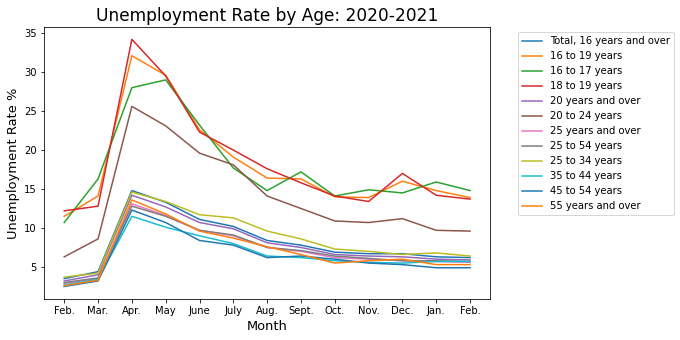

```python
rate_by_age.columns = rate_by_age.loc[0,:]
labels = []
for index, row in rate_by_age.iterrows():
    if "Men" in str(row[0]):
        break
    if "year" in str(row[0]):
        temp =  row.values.tolist()
        labels.append(temp[0])
        temp.pop(0)
        temp = [float(num) for num in temp]
        plt.plot(temp)

plt.legend(bbox_to_anchor=(1.05, 0.8, 0.3, 0.2), loc='upper left', labels=labels)
plt.xlabel("Month", size=13)
plt.ylabel("Unemployment Rate %", size=13)
plt.title("Unemployment Rate by Age: 2020-2021", size=17)

months = rate_by_age.columns.tolist()
months.remove(np.nan)
plt.xticks(range(0,13),months)

plt.show()
```

Based solely on the graph above, it is difficult to make any conclusions due to the large number of lines plotted. However, the graph seems to have two clumped portions that are separated from each other. The red, orange, green and brown lines are separated from the rest of the condensed graph. According to the legend, people in the lower age groups make up the top portion of the graph. Assumptions can be made based off the visualization that younger people, specifically under 24 years old, are unemployed at a higher rate than their older counterparts. To confirm these assumptions, I will create two sublists; one of the unemployment rate in the 16-24 age range and the other for 25 years and up.

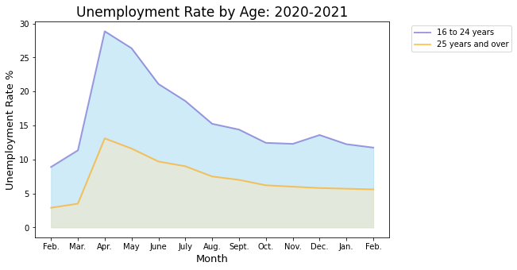

```python
#make a list of the unempoyment rates for 16 to 24 year olds
young1 = rate_by_age.loc[3,:].values.tolist()
young2 = rate_by_age.loc[7,:].values.tolist()
young1.remove('16 to 19 years')
young2.remove('20 to 24 years')
young = []
for i in range(0, len(young1)):
    young.append((float(young1[i]) + float(young2[i])) / 2)

#list of 25 and older
old = rate_by_age.loc[8,:].values.tolist()
old.remove('25 years and over')
old = [float(nums) for nums in old]

#area plot
plt.fill_between(np.arange(13), young, color="skyblue", alpha=0.4)
plt.plot(np.arange(13), young, color="Slateblue", alpha=0.6, linewidth=2)

plt.fill_between(np.arange(13), old, color="moccasin", alpha=0.4)
plt.plot(np.arange(13), old, color="orange", alpha=0.6, linewidth=2)

#labels for x axis
months = rate_by_age.columns.tolist()
months.remove(np.nan)
plt.xticks(range(0,13), months)

#axis and plot titles
plt.xlabel("Month", size=13)
plt.ylabel("Unemployment Rate %", size=13)
plt.title("Unemployment Rate by Age: 2020-2021", size=17)
#show legend
plt.legend(bbox_to_anchor=(1.05, 0.8, 0.3, 0.2), loc='upper left', labels=["16 to 24 years", "25 years and over"])
#show plot
plt.show()
```

This visualization gives a much better representation of the relationship between unemployment rates in younger and older people. There is a clear difference showing that people ages 16-24 have higher unemployment rates than people ages 25 and older. Although there is a visual difference between the two lines, further analysis is required to determine the significance of such difference.

```python
print("Average unemployment rate for ages 16 - 24 years:     ", sum(young)/len(young))
print("Average unemployment rate for ages 25 years and over: ", sum(old)/len(old))
```

```
Average unemployment rate for ages 16 - 24 years:      15.934615384615386
Average unemployment rate for ages 25 years and over:  7.199999999999999
```

The mean unemployment rate for people ages 16-24 is over double the rate of people 25 and over! Younger people lose their jobs at a rate more than two times higher than that of older people. While these numbers look like they would show significant difference, a statistical test can be conducted to strengthen the claim.

#### Statistical Testing

The Mann-Whitney rank test is an appropriate non-parametric test for this independent data. The null hypothesis will be that the two means are equivalent. H<sub>0</sub>: $\mu$<sub>young</sub> = $\mu$<sub>old</sub>. Given the values of the two means, the alternative hypothesis will test if the young unemployment rate is significantly higher than the old unemployment rate. H<sub>a</sub>: $\mu$<sub>young</sub> > $\mu$<sub>old</sub>

```python
print("p =", stats.mannwhitneyu(young, old, alternative='greater').pvalue, " < 0.05 ")
```

```
p = 7.385988395886396e-05  < 0.05
```

The alternative hypothesis is accepted as the p-value is < 0.05. It is accurate to claim that younger people (specifically 16-24 years old) have a significantly higher unemployment rate than older people (25+).

## Unemployment by Gender

The data used in this portion of the analysis comes from the rate dataset. In addition to unemployment rate by race, this set also contains unemployment rates of all men and all women ages 20 and over.

```python
rate['Men']
```

```
0      3.7
1      3.8
2      3.9
3      3.9
4      4.0
      ...
236    6.7
237    6.6
238    6.4
239    6.0
240    6.0
Name: Men, Length: 241, dtype: float64
```

```python
rate['Women']
```

```
0      3.7
1      3.6
2      3.7
3      3.8
4      3.9
      ...
236    6.5
237    6.2
238    6.3
239    6.0
240    5.9
Name: Women, Length: 241, dtype: float64
```

#### Visualization

Plotting unemployment rate by gender from 2001 to 2021. An area plot is used to highlight the difference between the two lines.

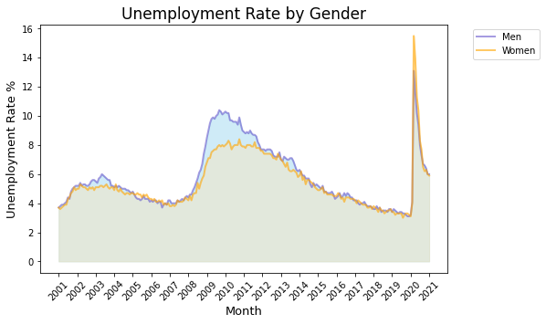

```python
plt.fill_between(np.arange(241), rate['Men'], color="skyblue", alpha=0.4)
plt.plot(np.arange(241), rate['Men'], color="Slateblue", alpha=0.6, linewidth=2)
plt.fill_between(np.arange(241), rate['Women'], color="moccasin", alpha=0.4)
plt.plot(np.arange(241), rate['Women'], color="orange", alpha=0.6, linewidth=2)


plt.xticks(rotation=45)
labels = ['Men', 'Women']
plt.legend(bbox_to_anchor=(1.05, 0.8, 0.3, 0.2), loc='upper left', labels=labels)
plt.ylabel("Unemployment Rate %", size=13)
plt.xlabel("Month", size=13)
ticks = []
months = []
for i in range(0, len(rate['Month']), 12):
    ticks.append(i)
    months.append(rate['Month'][i].replace("Feb ", ""))
plt.xticks(ticks, months)
plt.title("Unemployment Rate by Gender", size=17)
plt.show()
```

As shown by the visualization above, the unemployment rates for men and women are fairly similar. Between 2008 and 2012 the unemployment rate for men seems to be a little higher, but that is the only major difference visible on the graph.

```python
print("Unemployment average for men:   ", rate['Men'].mean(), "%")
print("Unemployment average for women: ", rate['Women'].mean(), "%")
```

```
Unemployment average for men:    5.73402489626556 %
Unemployment average for women:  5.397095435684648 %
```

The calculated means are also very similar, with a difference of less than 0.4%. My initial assumption would be that there is no statistical difference between these two means, however, a statistical test is required to prove the claim.

#### Statistical Testing

This data follows the same format as the previous sets of data. Similar to the other statistical tests, the Mann-Whitney rank test will be an appropriate non-parametric test for the independent data. The null hypothesis will be that the two means are equivalent. H<sub>0</sub>: $\mu$<sub>m</sub> = $\mu$<sub>w</sub>. Since the two means are so close together, the most appropriate alternative hypothesis would be that the two means are significantly different. H<sub>a</sub>: $\mu$<sub>m</sub> != $\mu$<sub>w</sub>

```python
print("p =", stats.mannwhitneyu(rate['Men'], rate['Women']).pvalue, " > 0.05")
```

```
p = 0.08142846141146426  > 0.05
```

Since the resulting p value is greater than 0.05, the alternative hypothesis fails to be accepted and the null hypothesis is held. It is accurate to state that the average unemployment rate for men and women are statistically the same. There is not enough evidence to claim that the two sample means are statistically different.

### Conclusion

When breaking down unemployment rates among the 4 racial groups provided, there is adequate evidence that the total average is statistically different from the average among these groups. The Black or African American and Hispanic or Latino groups displayed unfavorable results compared to the total average. The unemployment rates in these categories are significantly higher than the average unemployment rate. On the other hand, the White and Asian categories both have unemployment rates that are significantly lower than the average. These results conclude that a higher portion of Black and Hispanic people are unemployed than White and Asian people, which correlates to a racial bias favoring the latter. While the analysis has shown that there is a significant difference in unemployment rates among these groups, further testing in the future can provide a more accurate representation to the effect of such differences.

Through an analysis of unemployment rates by age, it has been concluded that people in the younger age group tend to be unemployed at a significantly higher rate than older people. People between the ages of 16 and 24 are more than twice as likely to be unemployed than someone who is 25 or older. A [study](https://www.tandfonline.com/doi/abs/10.1080/0361073X.2013.808111?casa_token=80xXV3TbU3oAAAAA%3AKPvWAAMs6GNG_rEqhbEf5-KnBrRUGSvguZgKrBgF2zukfb5t7QGrIIQS4ByfF2Z45Dj16IurC301&journalCode=uear20) conducted by Sanna Malinen displayed a negative implicit bias against older people. Additionally, the study showed an explicit positive bias towards older people. One can hypothesize that when it comes to terminating employees, an explicit positive bias may outweigh a negative implicit bias. Another possible hypothesis is that the biases that are present during the hiring stage aren't as prevalent in the termination stage. It is important to note that the data used in this part of the analysis had a different range from the data in the rest of the analysis. The time period of the rate dataset ranges from 2001 up to 2021, yet the age breakdown of unemployment rates was only available from Feb 2020 to Feb 2021. The small sample size in this analysis causes the accuracy of these results to be questioned in comparison to results from data with a sample size of over 200.

The final observations made were based on unemployment rates between men and women. Surprisingly, there was no significant difference between the unemployment rate for men and the unemployment rate for women. While multiple sources, such as [Berke](https://www.berkeassessment.com/blog-articles/gender-discrimination-how-recruiters-can-help) and [Forbes](https://www.forbes.com/sites/forbescoachescouncil/2020/03/16/how-does-sexism-influence-workplaces-today/?sh=2489306f7e51), argue the prevalence of sexism in the workplace, such sexism is not seen when it comes to the terminnation of an employee.

Based on these results, it is reasonable to conclude that a racial bias is present in the workplace. This racial bias has a negative impact on Black or Hispanic people while favoring White and Asian people. There is also an age bias favoring people that are 25 or older, however, the small sample size weakens the strength of this claim. Finally, no significant difference was shown in unemployment data among genders leading to the conclusion that a gender bias is not prevelant when it comes to terminating employees. Employers and policy makers can reflect on this analysis in an attempt to eliminate such biases from occuring.

### Sources

- Chisolm-Noel, Anadri. “Unconscious Bias: How It's Affecting Your Workplace.” IMPACT Group, 16 Mar. 2021, www.impactgrouphr.com/insights/unconscious-bias.
- Elliott, James R., and Ryan A. Smith. “Race, Gender, and Workplace Power.” American Sociological Review, vol. 69, no. 3, June 2004, pp. 365–386, DOI: 10.1177/000312240406900303
- Feigenbaum, Eric. “The Value of Diversity in the Workplace.” Small Business - Chron.com, Chron.com, 27 Nov. 2018, smallbusiness.chron.com/value-diversity-workplace-3035.html.
- Giroux, Scott. “Hiring Bias: Hidden Biases That Affect the Hiring Process.” Crowdstaffing, 2020, www.crowdstaffing.com/blog/hidden-bias-that-affect-the-hiring-process.
- Madsen, Susan. “Council Post: How Does Sexism Influence Workplaces Today?” Forbes, Forbes Magazine, 16 Mar. 2020, www.forbes.com/sites/forbescoachescouncil/2020/03/16/how-does-sexism-influence-workplaces-today/?sh=2489306f7e51.
- “Protections Against Discrimination and Other Prohibited Practices.” Federal Trade Commission, 1 May 2019, www.ftc.gov/site-information/no-fear-act/protections-against-discrimination.
- Sanna Malinen & Lucy Johnston (2013) Workplace Ageism: Discovering Hidden Bias, Experimental Aging Research, 39:4, 445-465, DOI: 10.1080/0361073X.2013.808111
- Stack, Meredith. “Gender Discrimination Starts in Recruiting.” Berke, www.berkeassessment.com/blog-articles/gender-discrimination-how-recruiters-can-help.
- U.S. Bureau of Labor Statistics, U.S. Bureau of Labor Statistics, 6 Apr. 2021, www.bls.gov/.